# The female rivalry hypothesis - Exploratory Analyses

Scott Claessens

2020-12-01

We run exploratory analyses on the mating behaviour of agents. The data in the main and sensitivity analyses only capture reproductive success and paternal investment after the whole model run. They do not capture mating behaviour (number of mates, number of unique mates, and amount of mate switching). To remedy this, we ran models on Netlogo v4 and collected data on the following variables, for each agent:

- **Number of mates**: total number of mating instances (including repeat matings)
- **Number of unique mates**: number of unique mates, out of 100 (there are only 100 of the opposite sex)
- **Amount of mate switching**: number of times the agent mates with an individual who was not their previous mate

First, we analysed only one simulation, under the conditions of Experiment 1 (No Aggression), to provide a proof of concept for the model. In this simulation, there were 100 males and 100 females, and it ran for 10,000 timesteps. The results are similar when the females are entirely Concealers or entirely Revealers, so we only report the results for Concealers both below.

Next, we ran 60 more simulations (20 for each experimental condition) and compared the mating histories of Concealers and Revealers in each, to further understand *why* Concealers enjoyed greater reproductive success in Experiment 3.

# 1. Proof of concept

Load the data from the one proof-of-concept simulation. We start by looking at the simulation in which all females were Concealers.

```r
d <-
  read.csv('data/v4/ovulationExploratory_ProofConcealers.csv') %>%
  as_tibble() %>%
  mutate(ID  = factor(ID),
         Sex = factor(Sex))

d
```

| ID | Sex | mate_value | male_promiscuity | num_matings | num_unique_mates | mate_switching |
| --- | --- | --- | --- | --- | --- | --- |
| 0 | female | 69.66850 | NA | 3882 | 90 | 1344 |
| 1 | female | 51.98346 | NA | 8571 | 43 | 207 |
| 2 | female | 57.43454 | NA | 6661 | 60 | 979 |
| 3 | female | 31.84945 | NA | 7634 | 57 | 276 |
| 4 | female | 51.36926 | NA | 8074 | 41 | 293 |
| 5 | female | 55.08718 | NA | 8026 | 47 | 254 |
| 6 | female | 45.41037 | NA | 7631 | 40 | 190 |
| 7 | female | 41.85339 | NA | 7602 | 55 | 525 |
| 8 | female | 58.34885 | NA | 8131 | 53 | 239 |
| 9 | female | 56.38662 | NA | 9094 | 42 | 177 |

[output cut: 190 more lines]

Let’s visualise the number of mating instances for both sexes.

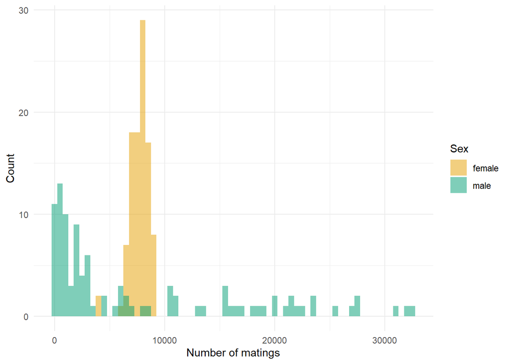

```r
p1 <-
  d %>%
  ggplot(aes(x = num_matings, fill = Sex)) +
  geom_histogram(binwidth = 500, alpha = .5, position = "identity") +
  xlab("Number of matings") +
  ylab("Count") +
  scale_fill_manual(values = c("#E69F00", "#009E73")) +
  theme_minimal()

# ggsave('figures/Figure_numMatings.pdf', p1, width = 150, height = 150, units = 'mm')

p1
```

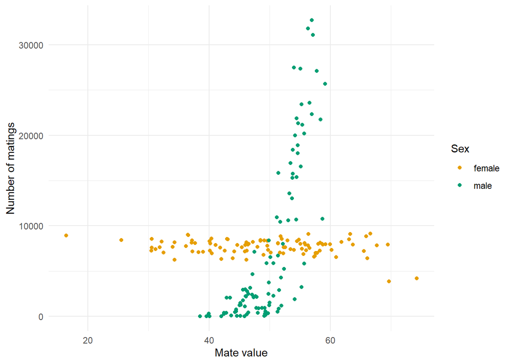

```r
p2 <-
  d %>%
  ggplot(aes(x = mate_value, y = num_matings)) +
  geom_point(aes(colour = Sex)) +
  xlab("Mate value") +
  ylab("Number of matings") +
  scale_colour_manual(values=c("#E69F00", "#009E73")) +
  theme_minimal()

# ggsave('figures/Figure_mateValue.pdf', p2, width = 150, height = 150, units = 'mm')

p2
```

```r
# correlation for males
cor.test(d[d$Sex == 'male',]$mate_value, d[d$Sex == 'male',]$num_matings)
```

```
##
##  Pearson's product-moment correlation
##
## data:  d[d$Sex == "male", ]$mate_value and d[d$Sex == "male", ]$num_matings
## t = 12.353, df = 98, p-value < 2.2e-16
## alternative hypothesis: true correlation is not equal to 0
## 95 percent confidence interval:
##  0.6896234 0.8469451
## sample estimates:
##       cor
## 0.7803408
```

```r
# correlation for females
cor.test(d[d$Sex == 'female',]$mate_value, d[d$Sex == 'female',]$num_matings)
```

```
##
##  Pearson's product-moment correlation
##
## data:  d[d$Sex == "female", ]$mate_value and d[d$Sex == "female", ]$num_matings
## t = -2.009, df = 98, p-value = 0.04729
## alternative hypothesis: true correlation is not equal to 0
## 95 percent confidence interval:
##  -0.380441378 -0.002567232
## sample estimates:
##        cor
## -0.1988851
```

It seems that higher mate-value males do most of the mating, while mate value has little effect for females.

Is mate value associated with proportion of mate switching (promiscuity)?

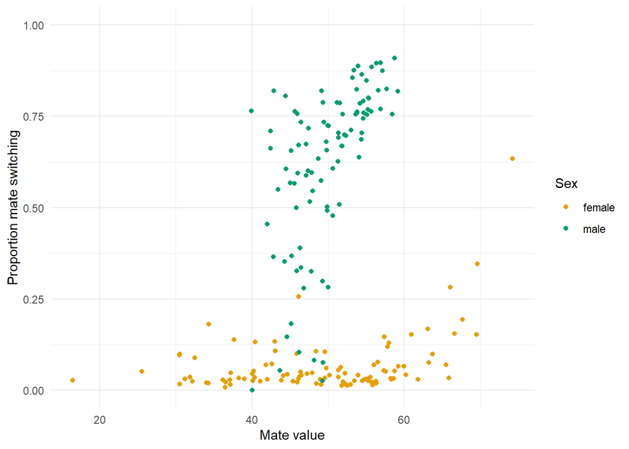

```r
d <-
  d %>%
  mutate(prop_mate_switching = mate_switching / num_matings)

p3 <-
  d %>%
  ggplot(aes(x = mate_value, y = prop_mate_switching)) +
  geom_point(aes(colour = Sex)) +
  xlab("Mate value") +
  ylab("Proportion mate switching") +
  ylim(0:1) +
  scale_colour_manual(values=c("#E69F00", "#009E73")) +
  theme_minimal()

# ggsave('figures/Figure_propMateSwitch.pdf', p3, width = 150, height = 150, units = 'mm')

p3
```

```r
# correlation for males
cor.test(d[d$Sex == 'male',]$mate_value, d[d$Sex == 'male',]$prop_mate_switching)
```

```
##
##  Pearson's product-moment correlation
##
## data:  d[d$Sex == "male", ]$mate_value and d[d$Sex == "male", ]$prop_mate_switching
## t = 6.7591, df = 96, p-value = 1.076e-09
## alternative hypothesis: true correlation is not equal to 0
## 95 percent confidence interval:
##  0.4163307 0.6886698
## sample estimates:
##       cor
## 0.5678427
```

```r
# correlation for females
cor.test(d[d$Sex == 'female',]$mate_value, d[d$Sex == 'female',]$prop_mate_switching)
```

```
##
##  Pearson's product-moment correlation
##
## data:  d[d$Sex == "female", ]$mate_value and d[d$Sex == "female", ]$prop_mate_switching
## t = 4.0523, df = 98, p-value = 0.0001017
## alternative hypothesis: true correlation is not equal to 0
## 95 percent confidence interval:
##  0.1970782 0.5354104
## sample estimates:
##       cor
## 0.3788318
```

The same effects hold when females are all Revealers (code in .Rmd file, but not shown here).

# 2. Mating Histories

Load the data for the more comprehensive exploratory analysis.

```r
d <-
  read.csv('data/v4/ovulationExploratory_Mating.csv') %>%
  as_tibble() %>%
  mutate(ftype      = factor(ifelse(ftype == 0, "Concealers", "Revealers")),
         Experiment = factor(Experiment),
         Simulation = factor(Simulation))

d
```

| Experiment | Simulation | ID | Sex | ftype | mate_value | male_promiscuity | num_matings | num_unique_mates | mate_switching | prop_mate_switching |
| --- | --- | --- | --- | --- | --- | --- | --- | --- | --- | --- |
| 1 | 1 | 0 | female | Revealers | 52.68792 | NA | 7125 | 72 | 335 | 0.047017544 |
| 1 | 1 | 1 | female | Revealers | 50.23739 | NA | 7610 | 62 | 535 | 0.070302234 |
| 1 | 1 | 2 | female | Revealers | 67.17941 | NA | 7941 | 58 | 721 | 0.090794610 |
| 1 | 1 | 3 | female | Revealers | 45.53959 | NA | 8852 | 38 | 90 | 0.010167194 |
| 1 | 1 | 4 | female | Revealers | 51.81703 | NA | 8859 | 52 | 179 | 0.020205441 |
| 1 | 1 | 5 | female | Revealers | 45.00605 | NA | 7029 | 66 | 322 | 0.045810215 |
| 1 | 1 | 6 | female | Revealers | 46.45227 | NA | 8093 | 48 | 778 | 0.096132460 |
| 1 | 1 | 7 | female | Revealers | 50.73569 | NA | 7008 | 62 | 420 | 0.059931507 |
| 1 | 1 | 8 | female | Revealers | 68.13285 | NA | 6891 | 76 | 2846 | 0.413002467 |
| 1 | 1 | 9 | female | Revealers | 38.05083 | NA | 8140 | 50 | 159 | 0.019533170 |

[output cut: 9990 more lines]

## 2.1. Number of matings

First, let’s plot number of matings for both strategies, in the three experiments.

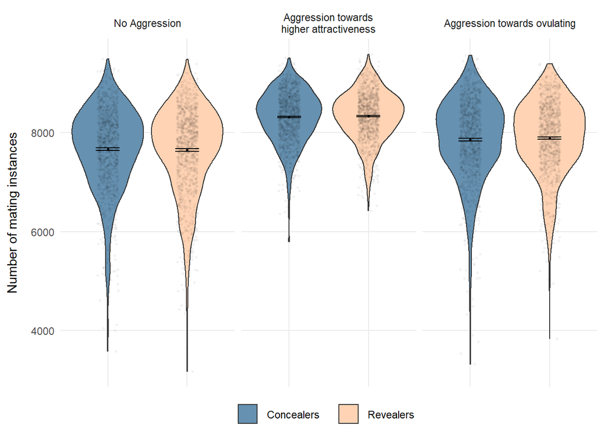

```r
num_matings_Summary <-
  d %>%
  group_by(Experiment, ftype) %>%
  summarise(num_matings_mean = mean(num_matings),
            num_matings_se   = sqrt(var(num_matings) / length(num_matings)))

facet_labels <- c(
    '1' = "No Aggression",
    '2' = "Aggression towards\nhigher attractiveness",
    '3' = "Aggression towards ovulating"
  )

p1 <-
  d %>%
  mutate(ftype = fct_relevel(ftype, c('Revealers', 'Concealers'))) %>%
  filter(Sex == 'female') %>%

  ggplot(aes(x = ftype, y = num_matings, fill = ftype)) +
  geom_violin(stat = "ydensity") +
  geom_jitter(colour = "black", size = 0.6, width = 0.13,
              alpha = 0.04, show.legend = FALSE) +
  geom_point(data = num_matings_Summary, aes(y = num_matings_mean),
             color = "black", size = 0.6, show.legend = FALSE) +
  geom_errorbar(data = num_matings_Summary,
                aes(y = num_matings_mean, ymin = num_matings_mean - num_matings_se,
                    ymax = num_matings_mean + num_matings_se),
                color = "black", width = 0.3) +
  facet_grid(. ~ Experiment, labeller = as_labeller(facet_labels)) +
  ylab('Number of mating instances') +
  scale_fill_manual(values=c("#6691b1", "#ffd3b4")) +
  theme_minimal() +
  theme(axis.title.x = element_blank(),
        axis.text.x  = element_blank(),
        axis.title.y = element_text(margin = margin(r = 10)),
        legend.title = element_blank(),
        legend.text  = element_text(margin = margin(r = 10, l = 2)),
        legend.position = 'bottom',
        legend.margin = margin(0,0,0,0),
        panel.grid.minor = element_blank())

# ggsave('figures/Figure_numMatingsExps.pdf', p1, width = 200, height = 110, units = 'mm')

p1
```

It doesn’t look the strategies differ in the amount of sex they are having, under any of the three conditions. Let’s conduct an ANOVA to test this intuition.

```r
d.females <-
  d %>%
  filter(Sex == 'female')

m1 <- aov(num_matings ~ Experiment*ftype + Error(Simulation/ftype), data = d.females)

summary(m1)
```

```
##
## Error: Simulation
##            Df    Sum Sq   Mean Sq F value   Pr(>F)
## Experiment  2 462717668 231358834   30.64 9.21e-10 ***
## Residuals  57 430393158   7550757
## ---
## Signif. codes:  0 '***' 0.001 '**' 0.01 '*' 0.05 '.' 0.1 ' ' 1
##
## Error: Simulation:ftype
##                  Df   Sum Sq Mean Sq F value Pr(>F)
## ftype             1    95568   95568   0.178  0.674
## Experiment:ftype  2   821199  410599   0.767  0.469
## Residuals        57 30526702  535556
##
## Error: Within
##             Df  Sum Sq Mean Sq F value Pr(>F)
## Residuals 5880 2.9e+09  493202
```

The ANOVA confirms this. The only statistical significance comes from the main effect of condition. It looks like this is driven by the increased number of matings under conditions of Aggression Towards Higher Attractiveness (Experiment 2).

## 2.2. Number of unique mates

Create plot for this new dependent variable.

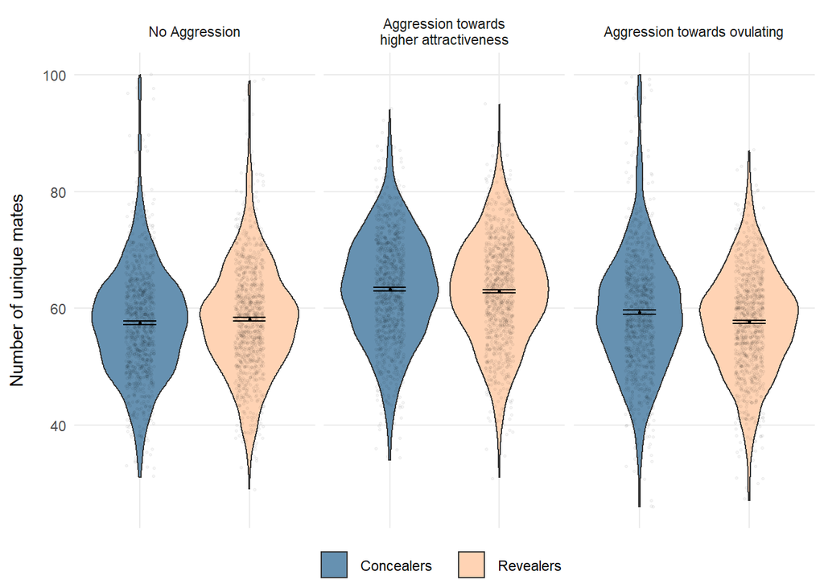

```r
num_unique_matings_Summary <-
  d %>%
  group_by(Experiment, ftype) %>%
  summarise(num_unique_matings_mean = mean(num_unique_mates),
            num_unique_matings_se   = sqrt(var(num_unique_mates) / length(num_unique_mates)))

p2 <-
  d %>%
  mutate(ftype = fct_relevel(ftype, c('Revealers', 'Concealers'))) %>%
  filter(Sex == 'female') %>%

  ggplot(aes(x = ftype, y = num_unique_mates, fill = ftype)) +
  geom_violin(stat = "ydensity") +
  geom_jitter(colour = "black", size = 0.6, width = 0.13,
              alpha = 0.04, show.legend = FALSE) +
  geom_point(data = num_unique_matings_Summary, aes(y = num_unique_matings_mean),
             color = "black", size = 0.6, show.legend = FALSE) +
  geom_errorbar(data = num_unique_matings_Summary,
                aes(y = num_unique_matings_mean,
                    ymin = num_unique_matings_mean - num_unique_matings_se,
                    ymax = num_unique_matings_mean + num_unique_matings_se),
                color = "black", width = 0.3) +
  facet_grid(. ~ Experiment, labeller = as_labeller(facet_labels)) +
  ylab('Number of unique mates') +
  scale_fill_manual(values=c("#6691b1", "#ffd3b4")) +
  theme_minimal() +
  theme(axis.title.x = element_blank(),
        axis.text.x  = element_blank(),
        axis.title.y = element_text(margin = margin(r = 10)),
        legend.title = element_blank(),
        legend.text  = element_text(margin = margin(r = 10, l = 2)),
        legend.position = 'bottom',
        legend.margin = margin(0,0,0,0),
        panel.grid.minor = element_blank())

# ggsave('figures/Figure_numUniqueMates.pdf', p2, width = 200, height = 110, units = 'mm')

p2
```

And we conduct another 2x3 mixed ANOVA.

```r
m2 <- aov(num_unique_mates ~ Experiment*ftype + Error(Simulation/ftype), data = d.females)

summary(m2)
```

```
##
## Error: Simulation
##            Df Sum Sq Mean Sq F value   Pr(>F)
## Experiment  2  32914   16457   25.32 1.35e-08 ***
## Residuals  57  37049     650
## ---
## Signif. codes:  0 '***' 0.001 '**' 0.01 '*' 0.05 '.' 0.1 ' ' 1
##
## Error: Simulation:ftype
##                  Df Sum Sq Mean Sq F value  Pr(>F)
## ftype             1    312   311.9   3.603 0.06273 .
## Experiment:ftype  2   1337   668.7   7.725 0.00108 **
## Residuals        57   4934    86.6
## ---
## Signif. codes:  0 '***' 0.001 '**' 0.01 '*' 0.05 '.' 0.1 ' ' 1
##
## Error: Within
##             Df Sum Sq Mean Sq F value Pr(>F)
## Residuals 5880 514322   87.47
```

It seems that the difference between strategies only exists in Experiment 3, supported by the significant interaction effect.

## 2.3. Proportion of mate switching (promiscuity)

Create final plot.

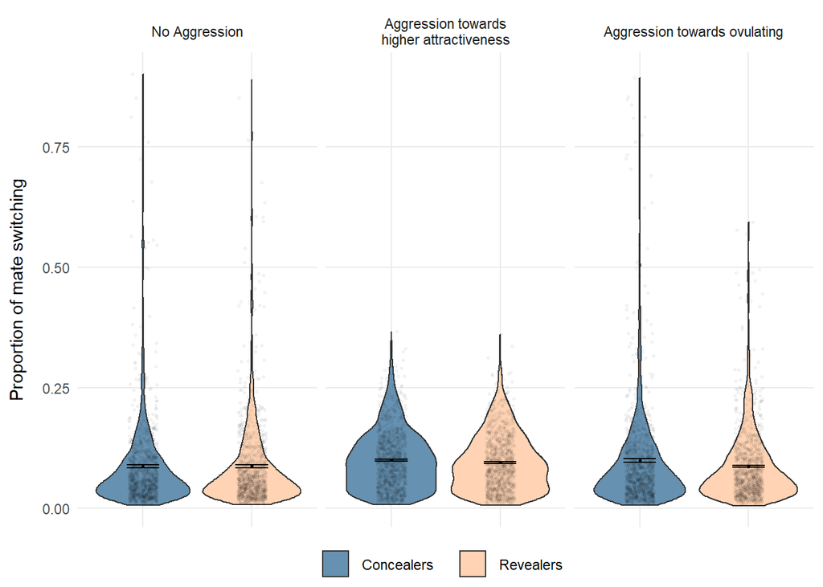

```r
prop_Summary <-
  d %>%
  group_by(Experiment, ftype) %>%
  summarise(prop_mean = mean(prop_mate_switching),
            prop_se   = sqrt(var(prop_mate_switching) / length(prop_mate_switching)))

p3 <-
  d %>%
  mutate(ftype = fct_relevel(ftype, c('Revealers', 'Concealers'))) %>%
  filter(Sex == 'female') %>%

  ggplot(aes(x = ftype, y = prop_mate_switching, fill = ftype)) +
  geom_violin(stat = "ydensity") +
  geom_jitter(colour = "black", size = 0.6, width = 0.13,
              alpha = 0.04, show.legend = FALSE) +
  geom_point(data = prop_Summary, aes(y = prop_mean),
             color = "black", size = 0.6, show.legend = FALSE) +
  geom_errorbar(data = prop_Summary,
                aes(y = prop_mean, ymin = prop_mean - prop_se,
                    ymax = prop_mean + prop_se),
                color = "black", width = 0.3) +
  facet_grid(. ~ Experiment, labeller = as_labeller(facet_labels)) +
  ylab('Proportion of mate switching') +
  scale_fill_manual(values=c("#6691b1", "#ffd3b4")) +
  theme_minimal() +
  theme(axis.title.x = element_blank(),
        axis.text.x  = element_blank(),
        axis.title.y = element_text(margin = margin(r = 10)),
        legend.title = element_blank(),
        legend.text  = element_text(margin = margin(r = 10, l = 2)),
        legend.position = 'bottom',
        legend.margin = margin(0,0,0,0),
        panel.grid.minor = element_blank())

# ggsave('figures/Figure_mateSwitching.pdf', p3, width = 200, height = 110, units = 'mm')

p3
```

Females rarely switch mates, but Concealers do slightly more in Experiment 3. Let’s conduct a final 2x3 mixed ANOVA.

```r
m3 <- aov(prop_mate_switching ~ Experiment*ftype + Error(Simulation/ftype), data = d.females)

summary(m3)
```

```
##
## Error: Simulation
##            Df Sum Sq Mean Sq F value Pr(>F)
## Experiment  2 0.1182 0.05910   1.329  0.273
## Residuals  57 2.5346 0.04447
##
## Error: Simulation:ftype
##                  Df Sum Sq Mean Sq F value Pr(>F)
## ftype             1 0.0452 0.04522   6.071 0.0168 *
## Experiment:ftype  2 0.0379 0.01894   2.542 0.0876 .
## Residuals        57 0.4246 0.00745
## ---
## Signif. codes:  0 '***' 0.001 '**' 0.01 '*' 0.05 '.' 0.1 ' ' 1
##
## Error: Within
##             Df Sum Sq  Mean Sq F value Pr(>F)
## Residuals 5880  40.82 0.006942
```

Though the interaction is not statistically significant, the low p-value suggests that there is a small effect.